# Final Project

Author

Bio724D: Fall 2023

Published

November 16, 2023

# **Instructions**

Create a Quarto markdown document and answer the questions below using code blocks that generate the correct outputs. We encourage you to include explanatory text in your markdown document, however **each of your solutions should show how to generate the answer using code chunks.**

Write “robust” solutions wherever possible. A good rule of thumb for judging whether your solution is appropriately “robust” is to ask yourself “If I added additional observations or variables to this data set, or if the order of variables changed, would my code still compute the right solution?”

Make sure your markdown is nicely formatted – use headers, bullets, numbering, etc so that the structure of the document is clear.

Make sure to “Render” your document before submission to confirm that all code blocks and formatting is as you expect.

When completed, title your markdown file as follows (replace `XX` with the assignment number, e.g. `01`, `02`, etc):

- `netid-assignment_XX-Fall2023.qmd`

Submit both your markdown file and the generated HTML document via the Assignments submission section on Sakai.

# The Data

**IMPORTANT!!!!** [An in-depth video explaining the data can be found HERE](https://drive.google.com/file/d/18zODrPJm3RwjR8QQJDQaVFdcYB_Rw_P-/view?usp=sharing). **Please watch this short >10min video before getting started.**

Briefly, you have been given a zipped directory “Raw Data.zip” which contains two kinds of files: .mats and .csvs. The .csvs are from three experiments, one where the group size was one (GS1), one where the group size was five (GS5) and one where the group size was 10 (GS10). We are only interested in the GS10 .csv files.

Each GS10 csv file corresponds to a single trial and contains the following:

- `X` and `Y` coordinates for each animal, where each row is a frame, and each animal’s tracks are stacked in long-format.
- `Animal` which tells you which animal was being tracked. There are 10 animals per trial.
- `Trial` which is the trial number. This should be the same as the trial number in the file name.
- `Date` which is the day the trial was conducted
- `Weather` which is the weather at the beginning of the trial, stored as “Cloudy” or “Sunny”
- `Temp` which is the temperature at the beginning of the trial in Fahrenheit
- `TOD` which is the time of day when the trial began (all trials were conducted in the morning)

Your task will be to select only the GS10 csv files from the directory, combine the raw track data and metadata from each trial into two files with all the trials combined in UNIX, and then wrangle/plot them in R (plus some other fun stuff along the way).

Notably, if you run into hiccups along the way and are unable to generate the files in the UNIX section, we have included them as well (TrackData.csv and MetaData.csv) so that you can see what they should look like, and can use them to finish the R section if needed.

Are you ready?

# Unix pipeline

## Problem 01: Data quality reports in Awk

Write an Awk script that given a Sandhopper experimental data file produces a “data quality” report for that file. Name your script `quality_reporter.awk`.

Your awk script should produce a report with the following pieces of information:

1. The name of the input file
2. A summary of how many individuals are represented in the file (there should be 10 in each file)
3. For each animal, a summary of the number of video frames that include no movement (NAs)
4. For each animal, the total number of video for which the X,Y position changed (rows with no NA values in X or Y)
5. For each animal, the total traversal time (including non-movement frames), in SI units (video filmed at 30 fps)

Example output is shown below for a valid `quality_reporter.awk` script run on the `GS10-T10xypts.csv` experiment file:

**Example output of `quality_reporter.awk` scipt**

```
Input file: GS10-T10xypts.csv

Number of animals: 10

## NA details
Animal 2 NA count: 0
Animal 3 NA count: 0
Animal 4 NA count: 0
Animal 5 NA count: 5
Animal 6 NA count: 0
Animal 7 NA count: 1
Animal 8 NA count: 0
Animal 9 NA count: 0
Animal 10 NA count: 0
Animal 1 NA count: 0

## Move details
Animal 2 move count: 101 frames, 3.36667 secs
Animal 3 move count: 160 frames, 5.33333 secs
Animal 4 move count: 86 frames, 2.86667 secs
Animal 5 move count: 115 frames, 3.83333 secs
Animal 6 move count: 132 frames, 4.4 secs
Animal 7 move count: 14 frames, 0.466667 secs
Animal 8 move count: 86 frames, 2.86667 secs
Animal 9 move count: 118 frames, 3.93333 secs
Animal 10 move count: 112 frames, 3.73333 secs
Animal 1 move count: 170 frames, 5.66667 secs
```

## Problem 02: File pre-processing in Bash

Write a bash script, `sandhopper_preprocessing.sh`, that accomplishes the following:

1. Creates a directory called `Groupsize_10`
2. Copies every “GS10” CSV file to the `Groupsize_10` directory
3. For every “GS10” CSV file in `Groupsize_10`, runs the file through your `quality_reporter.awk` script (above) and write the output to a corresponding file ending with the extension `.report`. For example, the input file `GS10_T41xypts.csv` will be used to generate the output `GS10_T41xypts.csv.report`.
   - Make sure each report file is also written to the `Groupsize_10` directory
4. Iterate over every “GS10” CSV file and extract the columns “X”, “Y”, “Animal”, and “Trial” (the first 4 columns), and concatenate these four columns from each input file to one combined file called `TrackData.csv`
   - Include a header column in `TrackData.csv` file with the column names
   - `TrackData.csv` should have 4 columns and 74,231 rows
5. Iterate over every “GS10” CSV file and extract the columns “Trial”, “Date”, “Weather”, “Temp”, and “TOD” (columns 4-8), and concatenate these five columns from each input file to one combined file called `MetaData.csv`
   - Include a header column in `MetaData.csv` file with the column names
   - `MetaData.csv` should have 5 columns and 47 rows

# R Pipeline

## First: Load the two files generated from the Unix pipeline, and then load the tidyverse package

Name the raw tracks file “Tracks” and the metadata file “MetaData”

## Problem 03: Plotting the Tracks

Here we are going to build a function to plot the animal’s paths for each trial, then we are going to write a loop to plot and save the figure for each track.

### Step A: Plotting a single trial

Make the figure below, which is the path for each animal from **Trial 1** (their X and Y coordinates).

You will need to use **theme_void, remove the X and Y axis text, title, and ticks, set linewidth=1, and remove the legend**.

In addition, **set the limits of the x and y axes to be the min and max X and Y coordinates, respectively, for ALL the animals** to ensure your figure is centered consistently no matter which trial you plot.

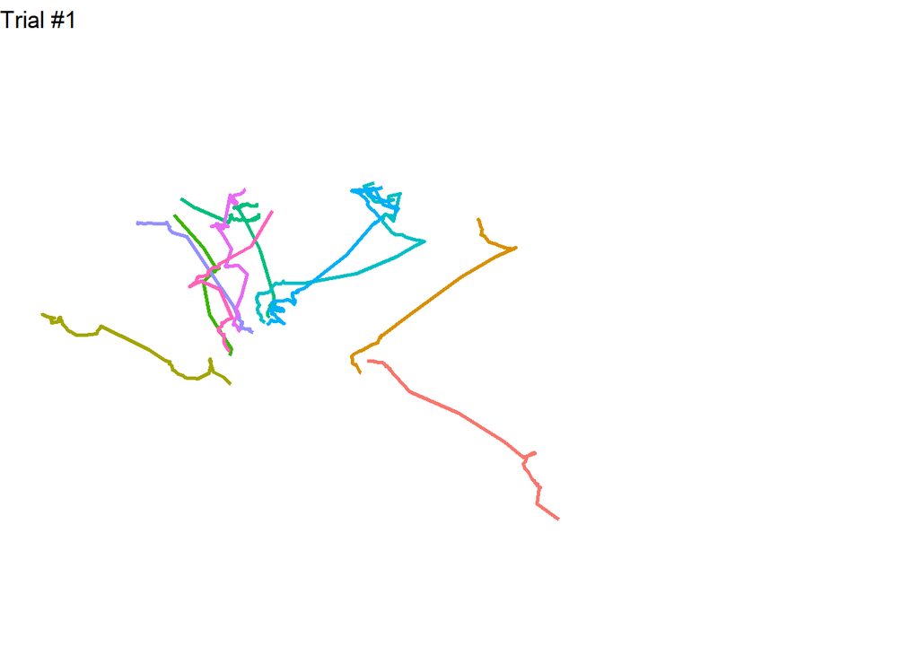

**Hint 1: Plotting only a single trial**

Think about using some of the dplyr verbs that we learned to get only the rows containing the trial you wish to plot

**Hint 2: Plotting the paths**

What type of data is the Animals column? What type of data would it need to be if we wanted to treat these as *individuals* rather than numbers on a number line?

What kind of ggplot geom is useful for making paths that connect points in the order they appear in the data, rather than from left to right?

Once you’ve found the right geom, take a look at the arguments. We know we can set grouping using things like color or shape, but is there an additional argument we can include to specify some sort of *group*?

**Hint 3: Setting the axes limits**

You can set the x-axis limits using `scale_x_continuous(limits=c(min#, max#))`. If you want to make sure that the limits are the same across all of the plots, you will need to set the min# and max# using the min and max values from the WHOLE dataset, not just the trial you are plotting. Don’t forget to use `na.rm=True`.

Once you’ve solved it for the x-axis, edit the code to repeat it for the y-axis

### Step B: Turning it into a function

Take the plot you just made and turn it into a function named `sandhoppers.plot`, where there are two arguments: 1) `Tracks` which is the full Tracks dataframe and 2) `TrialNum` which is the trial-number for the trial you wish to plot. **The title of the plot should be the trial number**, as shown below. This should automatically update with the input to your function, `TrialNum`.

**Test your function on Trial 7.**

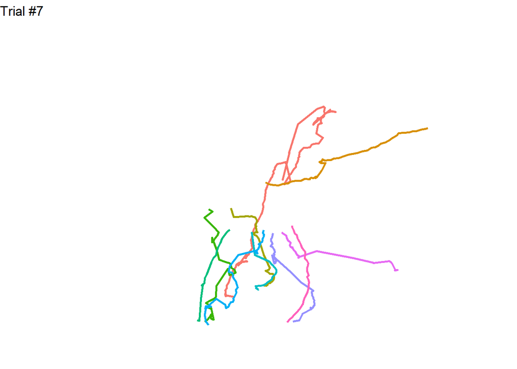

**Hint 1: Plotting the correct trial**

Think about using some of the dplyr verbs that we learned to get only the rows containing the trial you wish to plot in combination with the TrialNum argument to the function.

**Hint 2: Changing the title–small hint**

You can join text with the numeric output from a saved variable into a single string using `paste`, `paste0`, or `str_c` and you can set the title of your plot as a layer in ggplot.

**Hint 3: Changing the title–big hint**

One option would be to use `labs(title=paste0("Trial #",TrialNum))` where TrialNum is the second argument input to the function.

Now that you’ve seen this hint, could you accomplish the same thing with one of the other functions in hint 2?

**Hint 4: Outputting the plot**

As long as you do not assign the plot to a variable, and it is the last thing called in your function, it should automatically output when the function is run. If it’s still not outputting, try assigning the plot to p and using `paste` or `return`

### Step C: Looping across five trials

Write a loop that uses your function from above to plot the first five trials, as shown below. Remember, the trial numbers don’t run evenly from 1-46, so you will need a way to loop across the actual trial numbers. Hints can be found after the plots.

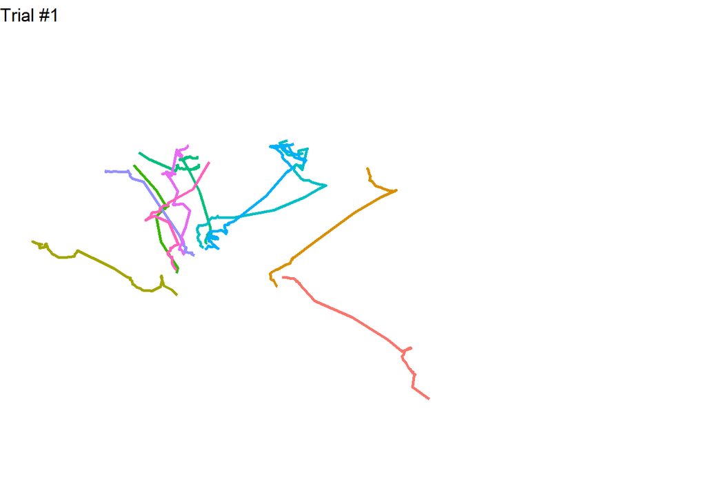

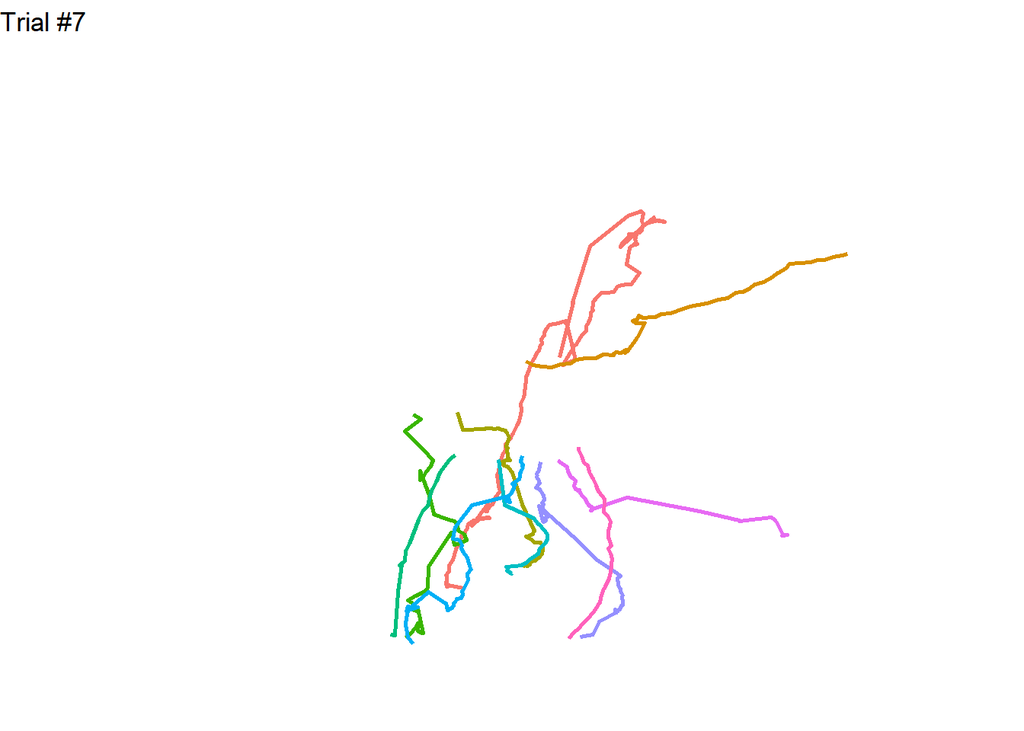

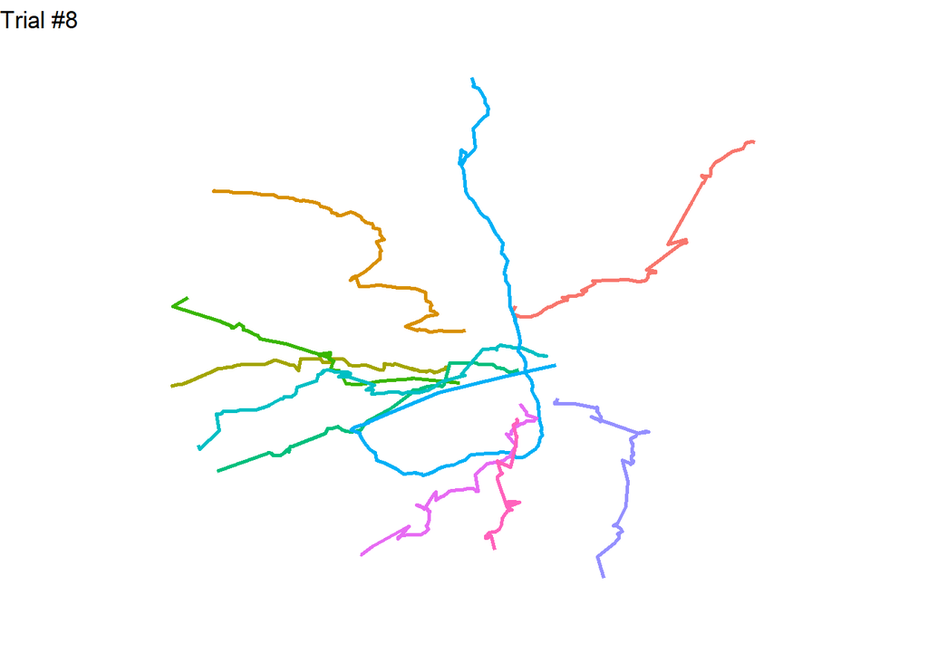

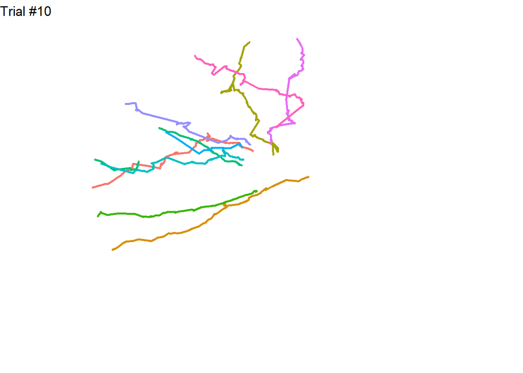

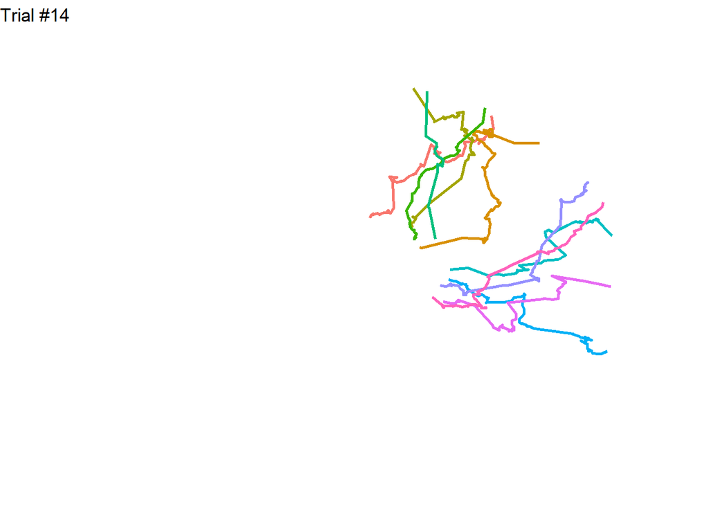

**Hint 1: Getting a vector of the trial numbers in order to loop across**

Start by making a vector named Trials that contains each of the trial numbers in numeric order. Think about using `sort` and `unique`

**Hint 2: Using the above vector to plot inside a loop–small hint**

To get the correct plot, think about using the Trials vector from above and indexing across it using i, where i runs from 1:5

**Hint 3: Using the above vector to plot inside a loop–big hint**

Use `sandhoppers.plot(Tracks,Trials[i])` where i runs from 1:5

**Hint 4: I think I did everything else right but my plot still isn’t outputting in-line?**

Your plot won’t output in line until print is called. Try assigning the output of your function to p (i.e. `p=sandhoppers.plot(Tracks, 7)` and then using `print(p)`.

### Step D: Looping across all of the trials and saving them to your computer

Use the loop from above, but this time loop over ALL of the trials, and save them to a folder on your computer called “Figures” using the function `ggsave().` **The name of each file should be Trial#.png where # corresponds to the correct trial number for the associated plot.** Embed a screenshot of your “Figures” folder to show that it worked correctly. Please do *not* include all 46 plots in your submission.

**Hint 1: Advice on getting started**

Try just saving one image outside of the loop to start. Then try saving just two images using the loop, before you try running the whole loop.

**Hint 2: Using ggsave()**

`ggsave` takes two relevant arguments, 1) the file path, PLUS the name of the image it is making PLUS the file **type** of the image it is making, and 2) the figure it is saving.

**Hint 3: More information on setting the file path in ggsave**

The file path needs to contain 1) the file path to the folder where you are saving the figures in (i.e. Bio 724/Final Project/Figures/) AND 2) the name of the figure you are saving (i.e. Trial1) AND 3) the file type information, (i.e .png or .jpg).

So the full file path should look something like this, depending on your working directory and file paths: “Bio724/Final Project/Figures/Trial1.png”

**Hint 4: Getting the name of the file to contain the correct trial number–small hint**

Remember that you can join text with the numeric output from a saved variable into a single string using `paste`, `paste0`, or `str_c`

**Hint 5: Getting the name of the file to contain the correct trial number–big hint**

One option would be to use `paste0("FilePath/Figures/Trial", Trials[i], ".png")`

Now that you’ve seen this hint, could you accomplish the same thing with one of the other functions in hint 4?

**Hint 6: Saving the correct figure**

If you are having issues getting the correct figure to save, think about assigning the output from the function to p (i.e. `p=sandhoppers.plot(Tracks, Trials[1])`) and then do `ggsave("FilePath", p)`.

### EXTRA CREDIT (just for funsies): Animating the paths

We can actually turn these paths into an animation of the animal’s movement over time–so fun!

First, load the package gganimate (FYI: if you love making these animations, [you can learn more about gganimate here](https://www.datanovia.com/en/blog/gganimate-how-to-create-plots-with-beautiful-animation-in-r/))

```r
library(gganimate)
```

Next, we need to add in a column for “time”. Remember, each row is a frame, so what we need to do is just group by the animal/trial, and add a column that is the row number for each individual (see code below). Look at the beginning of each animal to make sure this worked correctly. Each individual should start with 1

```r
Tracks.animation=Tracks |>
  group_by(Animal,Trial) |>
  mutate(Time=row_number())
```

Finally, we just take our plot from before, and add the line, `transition_reveal(Time)`.

- Note1: This may take a little time to render, be patient.
- Note2: When you run this in RStudio it will output to the viewer, not in line, but when you render it to html it will appear in line in the document.
- Note3: This works best if your function does NOT end with a print or return call, otherwise the still figure will also be output.

```r
TrialNum=1

p=sandhoppers.GS10.plot(Tracks.animation,TrialNum)

p+transition_reveal(Time)
```

You can save your animation if you want using `anim_save(filename="FileNameHere.gif")`

Extra EXTRA credit: Can you turn this into a function and then use a for loop to animate and save several of the trials like above? Be fore-warned, this will take a looooong time to run, so add a “progress-bar” of some kind to your loop to make sure it’s running and maybe only try it with 3-4 figures and not all 46.

## Problem 04: How does Weather, Temperature, Time-of-Day, and Smoke impact the animals movement?

We want to know how the **Weather**, **Temperature**, **Time of day**, and **Smoke** from the forest fire impacted the animal’s movements. Specifically, we want to know whether it changed the **VELOCITY** at which the animals’ moved, or how **WIGGLY** the path was that they took.

We can calculate their VELOCITY as: the distance between where they started the trial and where they ended the trial **divided by** the time it took them to complete the trial (we’ll convert this to be in units of inches per second)

We can calculate how WIGGLY their path was by calculating something called the “straightness index” which is: the distance between the beginning and end of their path (i.e. the distance they would have traveled if they moved in a perfectly straight line) **divided by** the distance they actually traveled (i.e. the sum of the distance between each step). This gives us a number bound between 0 and 1, where 1 is a perfectly straight line and 0 is Brownian motion (very wiggly).

Once we have both of these metrics calculated for every animal, we will then calculate the AVERAGE velocity and straightness index for each trial, and merge it with the metadata.

Let’s get started!

### Step A: Wrangling the data frame–Calculating the time and distances for each individual

**Your first task is to calculate the following variables for each individual:**

- The Time it took each animal to complete their track (in frames)
- The Straight Line Distance the animal moved (the distance between the beginning and end of their track)
- The Actual Distance the animal moved (the sum of the distance the animal moved each step)

To do this we will need to use three new functions we might not have seen before: `lag()`, `first()` / `last()`, and `n()`

- `lag()` gives you the value of the row that came BEFORE/ABOVE the current row. So if, for example, we wanted to make a new column that contained the value of each row minus the value of the row before it, we could do `mutate(NewColumn=OriginalColumn-lag(OriginalColumn)`. This will give us an NA for the first row (since there’s nothing before it) and otherwise would give us the value of each row minus the value of the preceding row. (Note: the function `lead()` does the same but in reverse, it gives the value of the row after/below of the current row). This is a vectorized function, like our vectorized `if_else()` statement, so it runs iteratively over each row, meaning we **don’t** need to use a for loop – yay!
- `first()`/`last()` gives you the value from the first/last row. This is particular useful when using a `group_by`, as it will give you the first and last value of the GROUPED data (i.e. the first/last value for each individual group, not just the first/last value of the whole dataframe)
- `n()` when used within a `summarise` will give you the total number of rows contained within each group.

**IMPORTANT: Remember, the formula to calculate the distance between two points is distance=sqrt( (X1-X2)^2 + (Y1-Y2)^2)**

We want to produce the following dataframe. Hints are below.

| Trial | Animal | Time | Dist_StrtLine | Dist_Actual |
| --- | --- | --- | --- | --- |
| 1 | 1 | 78 | 765.5952 | 902.1650 |
| 1 | 2 | 89 | 637.2314 | 854.8810 |
| 1 | 3 | 108 | 565.9304 | 812.5142 |
| 1 | 4 | 32 | 527.0350 | 588.9023 |
| 1 | 5 | 198 | 487.0451 | 941.5897 |
| 1 | 6 | 124 | 584.1995 | 1157.1564 |

**Hint 1: Calculating the values for each individual animal**

What dplyr functions allow you to *group* by the values in a column before doing calculations?

To isolate each individual, how many columns will be need to group by?

Where in our pipeline should this be called to ensure all future calculations are done by individual instead of on the whole dataframe?

**Hint 2: Calculating the distance the animal moved between each step**

Using the example given above for lag, think about making new columns that are `Diff_X=( X-lag(X) )^2` and `Diff_Y=( Y-lag(Y) ) ^2`. Then make a column that is the `sqrt( Diff_X + Diff_Y )`. This gives you the distance the animal moved between each step.

Make sure you’ve grouped correctly so that this applies separately to each animal (see hint 1).

You can make sure it worked correctly by confirming the first entry for each animal is an NA.

**Hint 3: Calculating the total distance the animal actually moved**

Now that you have the distance between each step (see hint 2), you just need to **sum** all of these distances for each animal. Think about using a `summarise` (don’t forget to set `na.rm=True`)

**Hint 4: Calculating the time it took each animal to complete the trial**

Remember, each row is one frame. Think about using `summarise` and `n()` to figure out the total number of rows for each animal (see hint 1 if needed).

(If you are having trouble reconciling this with the previous hint, remember, you can calculate more than one value in a single `summarise`.)

**Hint 5: Calculating the straight-line distance–small hint**

Think about using `first` and `last` in a `summarise` to calculate the difference between the x and y positions at the beginning and end of each animal’s trial

**Hint 6: Calculating the straight-line distance–big hint**

In a `summarise`, use `Diff_StrtLine_X = ( first(X) - last(X) )^2` and `Diff_StrtLine_Y = ( first(Y) - last(Y) )^2` then you can do `Dist_StrtLine = sqrt( Diff_StrtLine_X + Diff_StrtLine_Y) )`

### Step B: Wrangling the data frame–Calculating the MEAN Velocity and Straightness Index for each trial, then merging with the metadata

FIRST, calculate the Velocity and Straightness index for each individual using the values we just calculated in Step A:

- `Velocity=Dist_Straightline/Time`, BUT, we want the velocity in units of inches/second, so use `Velocity=( Dist_Straightline * (5/1000) ) / ( Time/30 )`
- `Straightness Index= Dist_Straightline/Dist_Actual`

NEXT: Once you have these values for each individual, **calculate the MEAN Velocity and Straightness Index for each TRIAL**.

THEN, **merge this new dataframe with the MetaData dataframe**

We want to produce the following dataframe:

| Trial | Velocity | StraighnessIndex | Date | Weather | Temp | TOD |
| --- | --- | --- | --- | --- | --- | --- |
| 1 | 1.0160091 | 0.6956074 | 7/21/2021 | Cloudy | 61 | 11:50 |
| 7 | 1.2172869 | 0.7150803 | 8/5/2021 | Sunny | 64 | 9:04 |
| 8 | 0.9031413 | 0.6574462 | 8/10/2021 | Sunny | 61 | 8:08 |
| 10 | 0.9621882 | 0.7099695 | 8.10.21 | Sunny | 61 | 8:55 AM |
| 14 | 1.0964088 | 0.6336892 | 8.11.21 | Sunny | 63 | 8:52am |
| 17 | 0.7967886 | 0.5575003 | 8.11.21 | Sunny | 72 | 10:02am |

**Hint 1: Calculating the velocity and straightness index for each individual**

What dplyr functions do we need to use to calculate these variables from the values we calculated in Step A?

**Hint 2: Calculating the mean for each trial**

We will need to change our grouping. Which column is no longer necessary to group by now that we want to calculate a mean over each TRIAL instead of for each ANIMAL?

Think about using this in combination with a `summarise`

**Hint 3: Joining with the metadata**

What kind of join do we need to do here? We want to keep ALL the values in the dataframe we just created, and match them to the corresponding values in the MetaData dataframe for each trial

### Step C: Examining the Affect of Forest Fires

On August 14th, 15th, and 16th of 2021 there was a severe forest fire near the area where the trials were being conducted. We want to see if the smoke from these fires affected the animal’s WIGGLINESS.

The goal here is to produce **AND INTERPRET** the figure below. To do this we will need need to do the following:

- Make the Date column a date-time object
- Make a new column where the rows are “Not Smoky” on days where there wasn’t a forest fire and are “Smoky” for Aug 14, 15 and 16 of 2021 (hint, look at the `replace` function)
- Rotate the dates in the x-axis of the figure (hint, first you will need to set the Date as a factor to plot the violin and scatterplot points correctly, then rotate)
- Set the colors to be dark green on non-smoky days and black on smoky days, and fiddle with the transparency of both layers
- Use theme_classic and set all text size to 15

| Trial | Velocity | StraighnessIndex | Date | Weather | Temp | TOD | Smoky |
| --- | --- | --- | --- | --- | --- | --- | --- |
| 1 | 1.0160091 | 0.6956074 | 2021-07-21 | Cloudy | 61 | 11:50 | Not Smoky |
| 7 | 1.2172869 | 0.7150803 | 2021-08-05 | Sunny | 64 | 9:04 | Not Smoky |
| 8 | 0.9031413 | 0.6574462 | 2021-08-10 | Sunny | 61 | 8:08 | Not Smoky |
| 10 | 0.9621882 | 0.7099695 | 2021-08-10 | Sunny | 61 | 8:55 AM | Not Smoky |
| 14 | 1.0964088 | 0.6336892 | 2021-08-11 | Sunny | 63 | 8:52am | Not Smoky |
| 17 | 0.7967886 | 0.5575003 | 2021-08-11 | Sunny | 72 | 10:02am | Not Smoky |

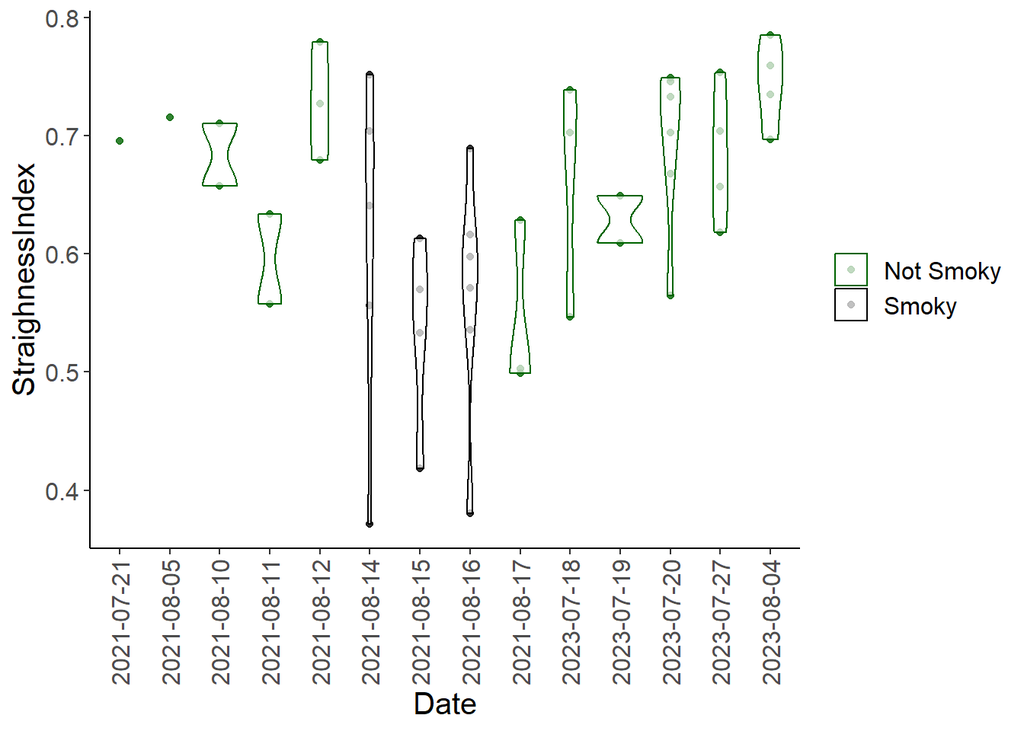

**Hint 1: Setting the non-smoky days**

Using `mutate` and `rep` make a new column called `Smoky` where every entry is “Not Smoky”

**Hint 2: Setting the smoky days–small hint**

It may be possible to use an `if_else` statement here, but it will be far easier to use the function `replace` inside a `mutate` where you replace the values in the column `Smoky` with “Smoky” in the rows where the date corresponds to **one** of the days of the forest fire (then repeat for all of the days)

**Hint 3: Setting the smoky days–big hint**

`mutate(Smoky=replace(Smoky,Date=="2021-08-14","Smoky"))`

Now repeat this for the other smoky days

**Hint 4: rotating the x axis**

Use `theme(axis.text.x = element_text(angle = 90, vjust = 0.5, hjust=1))`

**Hint 5: Setting the colors**

Use `scale_color_manual(values=c("darkgreen","black"))`

Don’t forget to interpret the above figure.

### Step D: Examining the Affect of Temp, TOD, and Weather

We want to look at the impact of Temp, TOD and Weather on the animals movement.

Since we have already determined that the forest fire has an impact, **remove all of the forest fire days from any future analysis. You should now have 31 rows.**

#### I) Temperature

First we will look at the impact of temperature. Make **and INTERPRET** the following figures using theme_classic; set all text size=15; set the size of the points to 3; use method=“lm” for the geom_smooth; set the limits for the y axis for the velocity plot to c(0,1.9) and for the straightness index plot to c(0,1). If you run into trouble, check to make sure the Temp column is numeric.

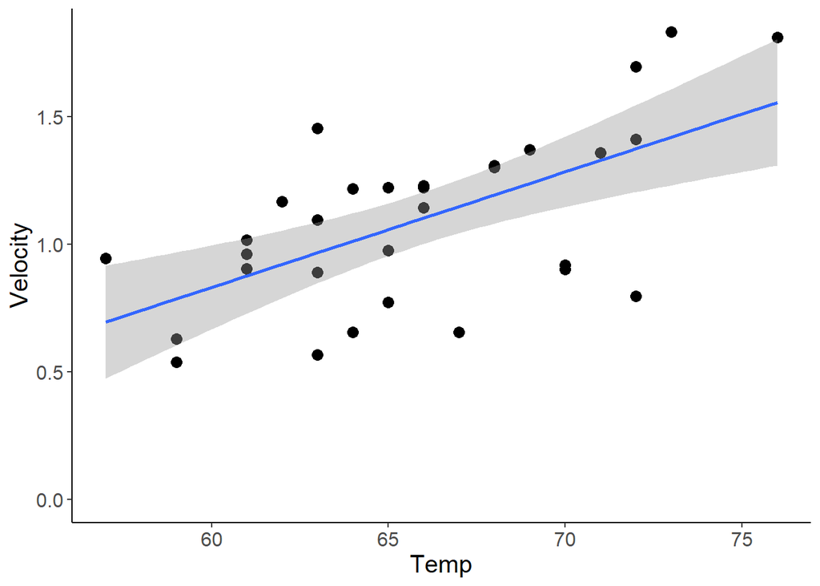

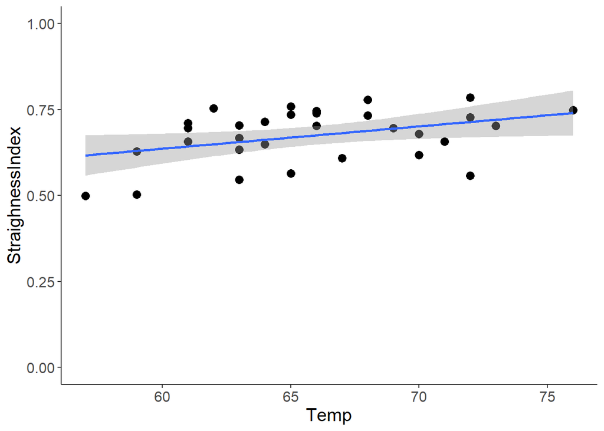

Don’t forget to interpret the figure!

#### II) Time-Of-Day

Next, we will look at the impact of Time-Of-Day (TOD). Take a look at the values in that column. What are some of the problems you notice?

We want to turn this into a numeric column that is the **number of minutes since midnight.** Use the functions `sub` and `separate_wider_delim`, to make the following data frame:

| Trial | Velocity | StraighnessIndex | Date | Weather | Temp | hour | minutes | Smoky | TOD |
| --- | --- | --- | --- | --- | --- | --- | --- | --- | --- |
| 1 | 1.0160091 | 0.6956074 | 2021-07-21 | Cloudy | 61 | 11 | 50 | Not Smoky | 710 |
| 7 | 1.2172869 | 0.7150803 | 2021-08-05 | Sunny | 64 | 9 | 04 | Not Smoky | 544 |
| 8 | 0.9031413 | 0.6574462 | 2021-08-10 | Sunny | 61 | 8 | 08 | Not Smoky | 488 |
| 10 | 0.9621882 | 0.7099695 | 2021-08-10 | Sunny | 61 | 8 | 55 | Not Smoky | 535 |
| 14 | 1.0964088 | 0.6336892 | 2021-08-11 | Sunny | 63 | 8 | 52 | Not Smoky | 532 |
| 17 | 0.7967886 | 0.5575003 | 2021-08-11 | Sunny | 72 | 10 | 02 | Not Smoky | 602 |

**Hint 1: Removing the AM and am–small hint**

The function `sub` will take one character or string and replace it with another. We want to replace ” AM” (note the space in front) and “am” with nothing ““. How could you use a dplyr verb to help you do this?

**Hint 2: Removing the AM and am–big hint**

`mutate(TOD=sub(' AM', '', TOD))`

Now modify this code to remove all the “am” as well

**Hint 3: Separating TOD into hour and minute**

Use `separate_wider_delim` with “:” as the deliminator. Set `names=c("hour", "minutes")`

**Hint 4: Calculating the minutes since midnight**

We want to make a new column, `TOD` that is the `hour` column, in minutes, plus the `minutes` column. There are 60 minutes in an hour, so first multiply the `hour` column by 60 (make sure the hour column is numeric), then add the `minutes` column

Now, make **AND INTERPRET** the following figures using theme_classic; set all text size=15; set the size of the points to 3; use use method=“lm” for the geom_smooth; set the limits for the y axis for the velocity plot to c(0,1.9) and for the straightness index plot to c(0,1).

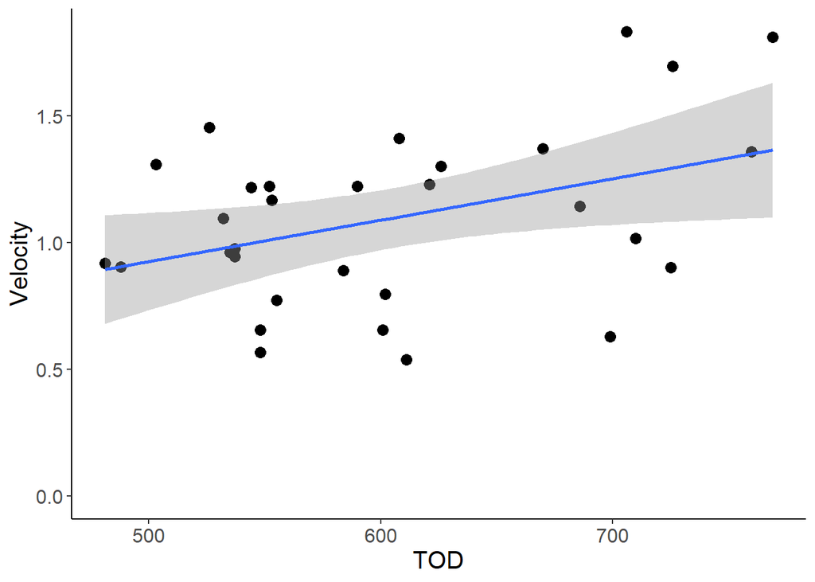

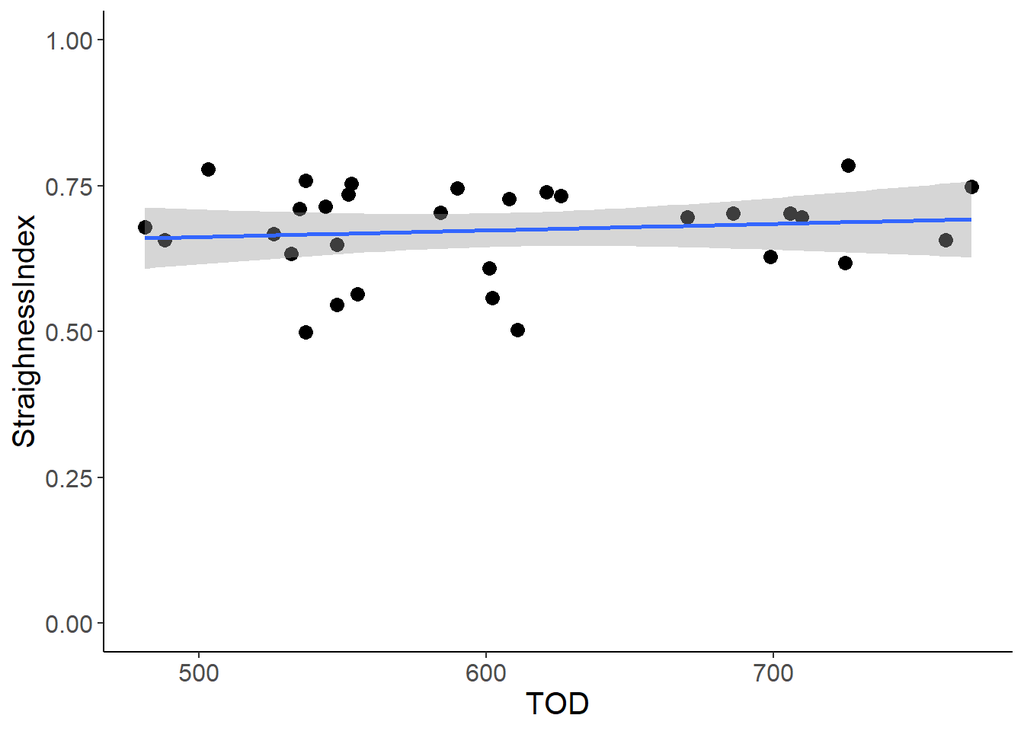

Don’t forget to interpret!

#### III) Weather

Next, we will look at the impact of Weather. At this point, if you filtered out the Smoky days, there should only be two values for weather, Cloudy and Sunny. Make **AND INTERPRET** the following figures using theme_classic; set all text size=15; set the limits for the y axis for the velocity plot to c(0,1.9) and for the straightness index plot to c(0,1); set the sunny day fill = yellow and the cloudy day fill = grey; set the transparency to = 0.5, and remove the legend

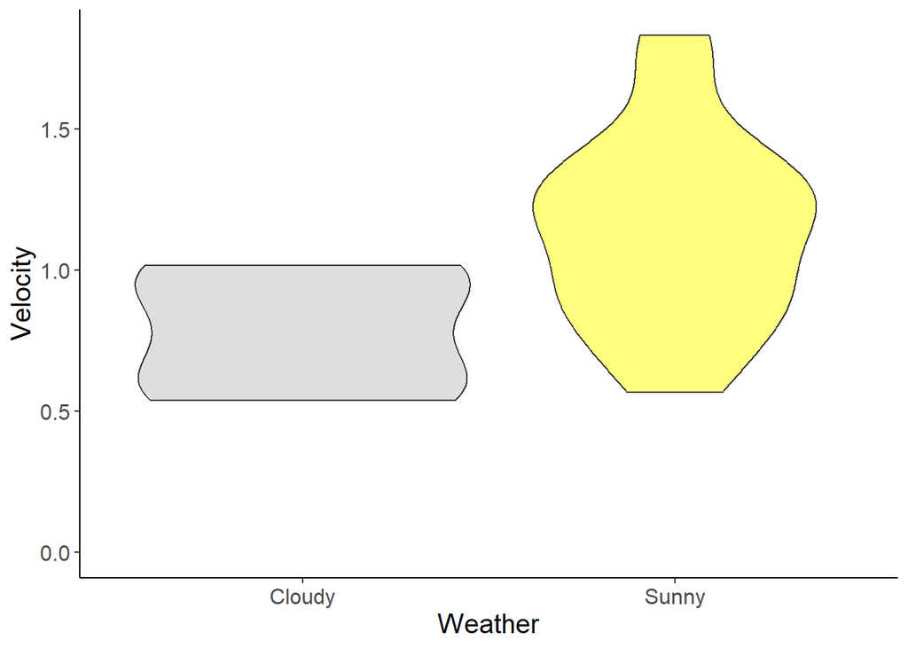

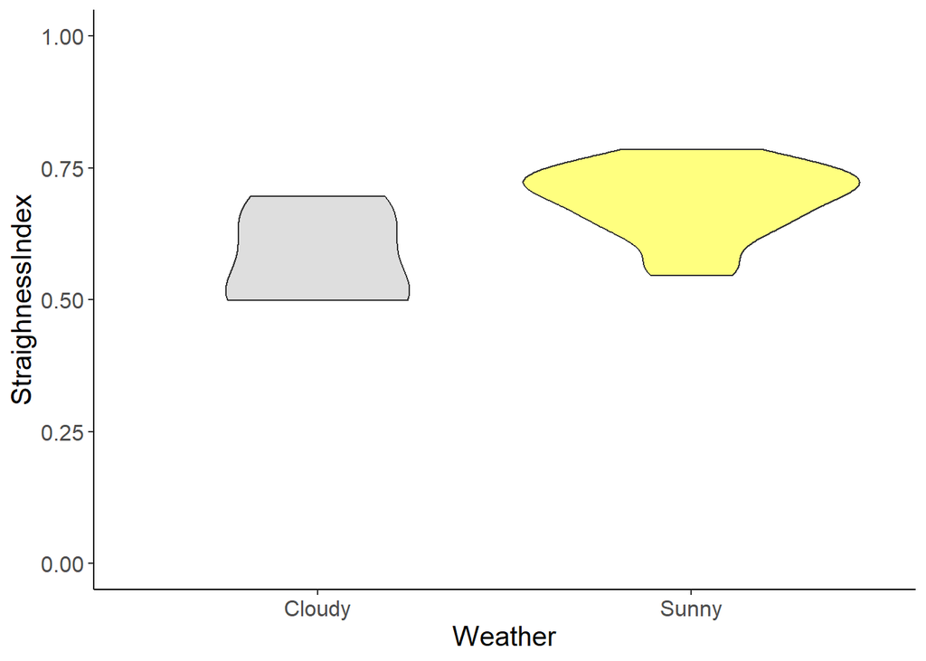

Don’t forget to interpret!

#### IV) Putting the plots together

Man, that sure is a lot of figures!

If we wanted to publish these results, we wouldn’t want to include 6 separate figures, so we are going to make **one** figure with parts A-F as shown here. To do this, we will need to load the library patchwork. ([See more information on the patchwork package here](https://patchwork.data-imaginist.com/)).

**Note that you will also need to remove the repetitive axes labels.** In other words, we only need the y-axis title, text, and ticks for the left-most plots, and we only need the x-axis title, text, and ticks for the bottom plots, since they’re repetitive/identical (or at least they should be, if you set the limits correctly)

Finally, label the figures A-F using the `plot_annotation(tag_levels="A)` function from the patchwork package.

```r
library(patchwork)
```

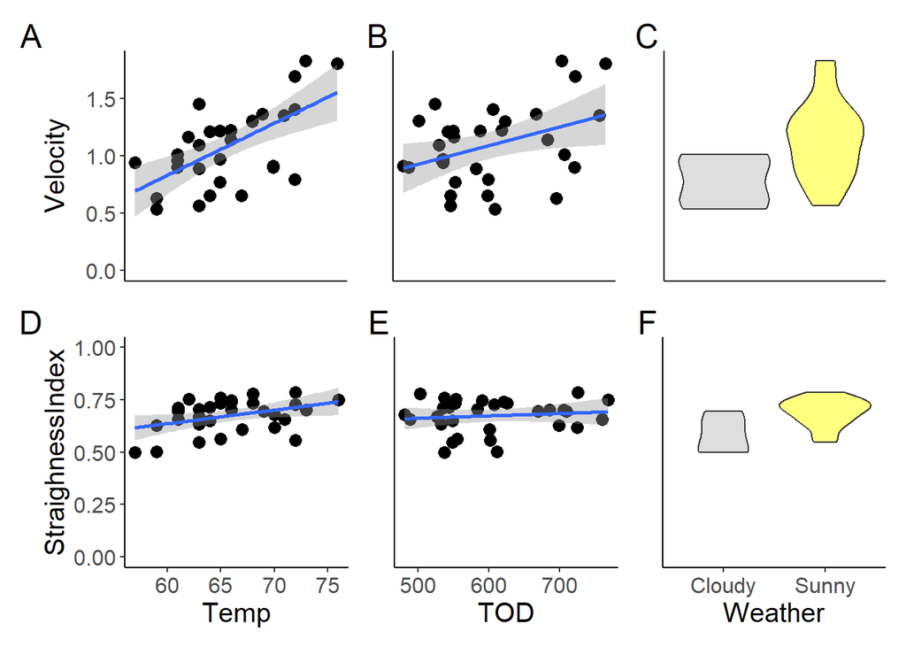

#### VI) Checking for co-variance

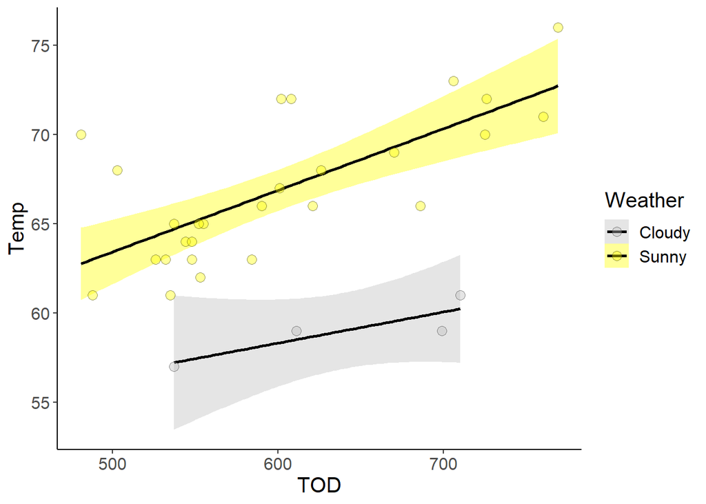